# assignment 3A

#### INSTRUCTIONS:

- Type your answers on the space provided under each problem.
- You can embed an R code chunk like this:

  ```r
  summary(cars)
  ```

  ```
  ##      speed           dist
  ##  Min.   : 4.0   Min.   :  2.00
  ##  1st Qu.:12.0   1st Qu.: 26.00
  ##  Median :15.0   Median : 36.00
  ##  Mean   :15.4   Mean   : 42.98
  ##  3rd Qu.:19.0   3rd Qu.: 56.00
  ##  Max.   :25.0   Max.   :120.00
  ```

- After you are done click the **Knit PDF** button. A document will be generated that includes both content as well as the output of any embedded R code chunks within the document.
- Go to File –> Save. Name your file.
- Upload the file to the Canvas site by using the link provided.

In this assignment we are going to explore the concept of sampling distributions and analysis of various types of data. Please type your commands below in the space provided.

##### Problem 1. (24 points)

First download the dataset MEASURESOFBIRTHANDDEATH.csv provided on the Canvas site and upload the file to RStudio (on the lower right window Files -> Upload, then follow the instructions). **a.** Read the file in RStudio by using read.csv() command.

##### Solution

One of the columns in the dataset is called LBW, which gives proportion of low birth weights (<2500 gr) for counties. In the problems that follow please non-standard values are NOT coded as NA. Make certain you remove them before doing the sampling.

**b.** Select a random sample of size 20 from LBW without replacement.

##### Solution

The **central limit theorem** states that if you take a large enough sample from any population, the sample mean will have an approximately Normal distribution with the mean being the same as the population and the standard deviation equal to the standard deviation of the population divided by the square root of the sample size. The standard deviation of the sample mean is known as the standard error of the sample mean.

**h.** Take a 100 samples of size 20 and find the mean for each with and without replacement. Write the code so that the results will be saved in the variables `meanreplaced` and `meannotreplaced`, respectively.

##### Solution

**k.** Find the 5th and 95th percentiles by using quantile() function for the all of the observations, `meanreplaced` and `meannotreplaced`.

##### Problem 2. (4 points)

**Range** in statistics is a measure of variation and defined as follows: Range = Maximimum Value - Minimum Value. **Write** a new function called MyRange to calculate this measure for a numerical input vector and **test** it on LBW variable in the MEASURESOFBIRTHANDDEATH.csv file.

##### Problem 3. (4 points)

**Write** a function that takes two search strings (by using twitteR) as arguments and that returns the results of a Poisson rate ratio test on the arrival rates of tweets on the two topics. Your function should first run the necessary Twitter searches, then sort the tweets by ascending time of arrival and calculate the two vectors of time differentials. Use the mean of one of these vectors as the basis for comparison and for each vector, count how many events are at or below the mean. **Use** this information and the numbers of tweets requested to run the poisson.test() rate comparison.

##### Problem 4. (10 points)

Now we will produce a word cloud to analyze text data. To see an interesting exammple of word cloud visit http://shiny.rstudio.com/gallery/word-cloud.html. Here are the step by step instructions:

**Step 1.** Copy and paste the all of the content of Chapter 13 into a Microsoft Word document. Go to `File -> Save as`, click on New Folder and name it temp. Click on create. Select Plain Text (.txt) from Format menu. On the Save As: window type chapter13. Click on Save. On the window that appears click OK.

**Step 2.** Compress (zip) the temp folder. Run RStudio Server and upload the zip file (Files -> Upload)

**Step 3.** We need the text mining package (‘tm’) and the wordcloud package (‘wordcloud’). So let us install and load these packages.

Go to Packages -> Install on the RStudio (lower right window) and type tm. Again, go to Packages -> Install on the RStudio (lower right window) and type wordcloud.

**Step 4.** Now we will do the text mining and clean up.

```r
chapter13 <- Corpus (DirSource("temp/"))
```

To see what’s in that corpus, type the following command (I’m disabling the following code chunk to keep `inspect` from executing…. it tends to display a lot of information and we don’t want that in our homework output)

```r
inspect(chapter13)
```

Let us try to produce word cloud to what we have

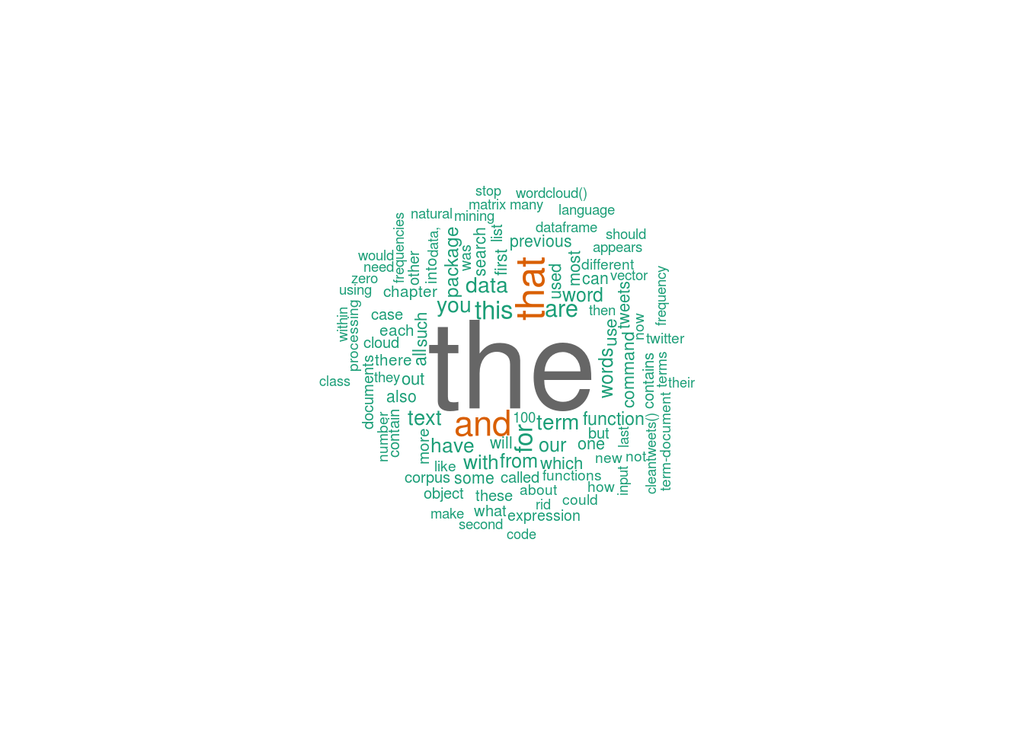

```r
wordcloud(chapter13, scale=c(5,0.5), max.words=100, random.order=FALSE, rot.per=0.35, use.r.layout=FALSE, colors=brewer.pal(8, "Dark2"))
```

English common words are called ‘stopwords’. To remove them type

```r
chapter13 <-tm_map(chapter13,content_transformer(tolower))        # Convert all words to lowercase (else next step fails)
chapter13 <- tm_map(chapter13, removeWords, stopwords("english")) # remove the stopwords
```

Let us try again

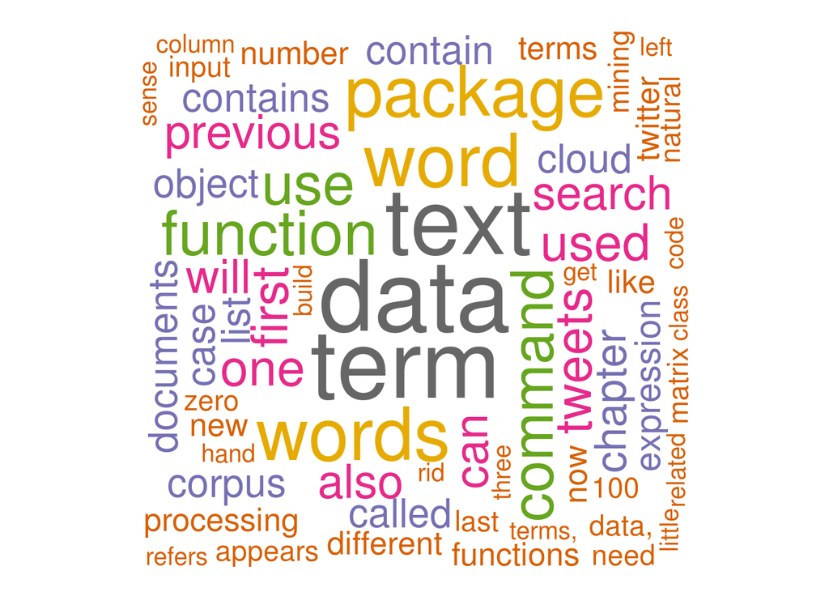

```r
options(warn=-1) #supress warnings
wordcloud(chapter13, scale=c(5,0.5), max.words=100, random.order=FALSE, rot.per=0.35, use.r.layout=FALSE, colors=brewer.pal(8, "Dark2"))
```

Now produce a word cloud for Chapter 7. If you want to get fancy figure out how to remove all the punctuation first.

##### Total Number of Points Earned: /38

Quick Access: